# TCGA Kinase Mutation Location Analysis

```r
library(tidyverse)
library(DarkKinaseTools)
library(here)
library(BerginskiRMisc)
library(broom)
```

## Data Loading and Organizing

The raw data consists of the mutations in each of the kinases detected in the TCGA data set. In addition, the start and stop location of each kinase was loaded from the kinase.com list and put into the DarkKinaseTools package. The following code parses the location of each protein changing mutation from the TCGA list and then determines if this location is between the start and stop location of the appropriate kinase.

```r
kinase_MAF = read_rds(here('mutant_analysis','data','kinase_MAF.rds')) %>%
  #lets only deal with changes that actually modify the protein sequence, so no
  #mutations to splice sites, 5'-UTR...
  #Note that this still includes the Silent mutations
  filter(Protein_Change != "")
#this regexp captures the number between the two amino acid one-letter codes,
#note that * is used to signify the nonsense mutations
mutation_locations = str_match(kinase_MAF$Protein_Change,"p.[[:alpha:]](\\d+)[[[:alpha:]]|*]")
kinase_MAF$Mutation_location = as.numeric(mutation_locations[,2])
#There are some more complicated mutation codes (~900) in the Protein Change
#column, these appear to mostly be related to frame shifts. Let's not deal with
#those.
kinase_MAF = kinase_MAF %>% filter(!is.na(Mutation_location))
kin_domain_locations = suppressMessages(left_join(kin_domain_locations,all_kinases)) %>%
  select(start, stop, protein_length, symbol, class)
kinase_MAF = suppressWarnings(left_join(kinase_MAF,kin_domain_locations,by=c("Hugo_Symbol"="symbol"))) %>%
  #some of the kinases don't have IDed domains in the kinase.com data, so let's get rid of them
  filter(!is.na(start) & !is.na(stop))
#OK, we've got the start and stop location of the kinase domains, so let's run
#through and mark hits inside the domain and outside the domain. Also, between
#doesn't appear to work like other dplyr functions (maybe it isn't dplyr), so
#I'll need a for loop. This takes some time.
kinase_MAF = kinase_MAF %>% mutate(In_Kin_Domain = 0)
for (row_num in 1:dim(kinase_MAF)[1]) {
  kin_data = kinase_MAF[row_num,]
  if (between(kin_data$Mutation_location,kin_data$start,kin_data$stop)) {
    kinase_MAF$In_Kin_Domain[row_num] = 1;
  }
}
```

## Data Analysis

```r
top_dark_kinases = kinase_MAF %>%
  filter(Variant_Classification != "Silent", class == "Dark") %>%
  group_by(Hugo_Symbol) %>%
  summarise(total_mutations_in_domain = sum(In_Kin_Domain),
            total_mutation_count = n()) %>%
  top_n(10,total_mutations_in_domain) %>%
  arrange(desc(total_mutations_in_domain))
bottom_dark_kinases = kinase_MAF %>%
  filter(Variant_Classification != "Silent", class == "Dark") %>%
  group_by(Hugo_Symbol) %>%
  summarise(total_mutations_in_domain = sum(In_Kin_Domain),
            total_mutation_count = n()) %>%
  arrange(total_mutations_in_domain) %>%
  slice(1:10)

top_light_kinases = kinase_MAF %>%
  filter(Variant_Classification != "Silent", class == "Light") %>%
  group_by(Hugo_Symbol) %>%
  summarise(total_mutations_in_domain = sum(In_Kin_Domain),
            total_mutation_count = n()) %>%
  top_n(10,total_mutations_in_domain) %>%
  arrange(desc(total_mutations_in_domain))
bottom_light_kinases = kinase_MAF %>%
  filter(Variant_Classification != "Silent", class == "Light") %>%
  group_by(Hugo_Symbol) %>%
  summarise(total_mutations_in_domain = sum(In_Kin_Domain),
            total_mutation_count = n()) %>%
  arrange(total_mutations_in_domain) %>%
  slice(1:10)
knitr::kable(top_light_kinases, caption = "Light Kinases with the Most Mutations in the Kinase Domain")
```

| Hugo_Symbol | total_mutations_in_domain | total_mutation_count |
| --- | --- | --- |
| BRAF | 675 | 760 |
| EGFR | 243 | 724 |
| STK11 | 194 | 245 |
| KIT | 161 | 431 |
| RPS6KA6 | 154 | 444 |
| TGFBR2 | 138 | 209 |
| ATM | 136 | 770 |
| MAP2K4 | 129 | 150 |
| MET | 128 | 325 |
| ACVR1B | 127 | 163 |

```r
knitr::kable(bottom_light_kinases, caption = "Light Kinases with the Least Mutations in the Kinase Domain")
```

| Hugo_Symbol | total_mutations_in_domain | total_mutation_count |
| --- | --- | --- |
| KALRN | 0 | 523 |
| EPHA6 | 1 | 346 |
| PDPK1 | 8 | 34 |
| PIM3 | 11 | 20 |
| TNK1 | 11 | 43 |
| AKT1 | 14 | 78 |
| AATK | 15 | 104 |
| PRKCZ | 15 | 46 |
| AURKA | 16 | 35 |
| MINK1 | 16 | 80 |

```r
knitr::kable(top_dark_kinases, caption = "Dark Kinases with the Most Mutations in the Kinase Domain")
```

| Hugo_Symbol | total_mutations_in_domain | total_mutation_count |
| --- | --- | --- |
| TSSK1B | 91 | 121 |
| CDK12 | 83 | 258 |
| STK31 | 80 | 298 |
| STK32B | 77 | 120 |
| ADCK1 | 73 | 97 |
| CSNK1A1L | 73 | 96 |
| DYRK3 | 66 | 106 |
| CAMK1D | 65 | 99 |
| CDK14 | 64 | 99 |
| STK3 | 60 | 95 |

```r
knitr::kable(bottom_dark_kinases, caption = "Dark Kinases with the Least Mutations in the Kinase Domain")
```

| Hugo_Symbol | total_mutations_in_domain | total_mutation_count |
| --- | --- | --- |
| DYRK4 | 3 | 125 |
| TP53RK | 5 | 5 |
| NRBP2 | 11 | 27 |
| STK36 | 12 | 157 |
| SCYL1 | 13 | 82 |
| ALPK3 | 16 | 245 |
| BCKDK | 18 | 54 |
| NEK9 | 18 | 80 |
| CDC42BPG | 20 | 158 |
| TBCK | 20 | 107 |

## Data Analysis

There are probably lots of ways to analyze this data, but my first thought is to simply count the percentage of mutations inside the kinase domain and compare this value to the percentage of each protein that is part of the kinase domain. How about this:

$$100*(\frac{\text{# hits in domain}}{\text{# hits total}} - \frac{\text{total domain lengths}}{\text{total protein length}}) = \text{Kinase Domain Enrichment Score (KDES)}$$

As for what makes a high or low value, let’s assume that the silent (non-protein changing) mutations are evenly distributed across each protein, so the predicted KDES for silent mutations should be zero. I’ve also filtered this to only deal with genes/mutation type interactions with at least 5 hits.

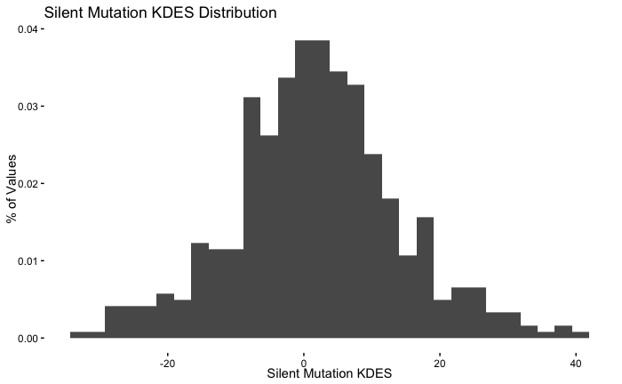

```r
kinase_KDES = kinase_MAF %>%
  group_by(Hugo_Symbol,Variant_Classification) %>%
  mutate(percent_kin_domain = (stop - start)/protein_length) %>%
  summarise(percent_in_domain = round(mean(In_Kin_Domain)*100,1),
            percent_kin_domain = round(first(percent_kin_domain)*100,1),
            count = n()) %>%
  mutate(KDES = percent_in_domain - percent_kin_domain) %>%
  filter(count >= 5)
kinase_silent_KDES = kinase_KDES %>% filter(Variant_Classification == "Silent")
ggplot(kinase_silent_KDES,aes(x=KDES)) + geom_histogram(aes(y= ..density..),bins=30) +
  theme_berginski() + labs(x="Silent Mutation KDES",y='% of Values') + ggtitle('Silent Mutation KDES Distribution')
```

This certainly looks like it’s centered around 0. The mean is 1.9%, the 95% conf int is (0.8%, 3%). Of these KDES values about 95% reside from -25% - +25%, let’s assume this is the natural variation in the value, so let’s mark these values in the other mutation types and take a look at them.

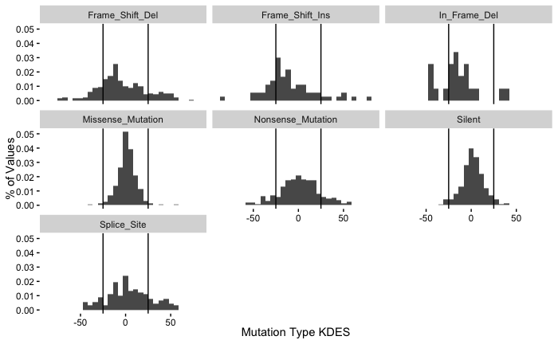

```r
ggplot(kinase_KDES,aes(x=KDES)) + geom_histogram(aes(y= ..density..),bins=30) +
  theme_berginski() + labs(x="Mutation Type KDES",y='% of Values') +
  geom_vline(aes(xintercept = -25)) + geom_vline(aes(xintercept = 25)) +
  facet_wrap( ~ Variant_Classification, ncol=3)
```

```r
nonsense_kinase_KDES = kinase_KDES %>%
  filter(Variant_Classification == "Nonsense_Mutation", KDES < -25 | KDES > 25)
nonsense_kinase_KDES = left_join(nonsense_kinase_KDES,select(all_kinases,c('symbol','class')),by=c('Hugo_Symbol'='symbol'))
```

```
Column `Hugo_Symbol`/`symbol` joining character vector and factor, coercing into character vector
```

```r
nonsense_kinase_KDES = nonsense_kinase_KDES %>% filter(class == "Dark") %>%
  arrange(KDES)
```